# RC2 Spatial Analyses

RED

01/08/2024

This file details the analyses performed on the spatially-resolved samples collected as part of the RC SFA at PNNL.

## Setup

```r
# General options
knitr::opts_chunk$set(cache = F)
options(digits = 10)
set.seed(2414)

# Load in packages
library(tidyverse)
library(reshape2)
library(ggpointdensity)
library(GGally)
library(ggrepel)
library(ggpubr)
library(gridExtra)
library(kableExtra)
library(Hmisc)
library(mgcv)
library(vegan)
library(picante)
library(Rfast)
library(tidyverse)
source("src/bMNTD_Fast.R")
```

## Load in data and perform initial cleaning

This section of code loads in most of the data for analysis, performs some data reorganization, and **importantly** removes duplicate molecular formula from the dataset.

```r
# Load in ICR data
data = read.csv("Data/Processed_RC2_SPS_11-2021_Data.csv", check.names = F, row.names = 1)
mol = read.csv("Data/Processed_RC2_SPS_11-2021_Mol.csv", check.names = F, row.names = 1)

# Load in metadata
meta1 = read.csv("v3_SFA_SpatialStudy_2021_SampleData/SPS_Sample_Field_Metadata.csv")
meta2 = read.csv("v3_SFA_SpatialStudy_2021_SampleData/SPS_Sample_IGSN-Mapping.csv", skip = 1) %>% dplyr::select(Site_ID = 'Locality', Location = 'Physiographic_Feature_Name' )%>% distinct()

meta = merge(meta1, meta2, by = 'Site_ID')
rm(meta1, meta2)

# Adjusting column name
colnames(meta) = gsub("Sample_Name", "Site", colnames(meta))
colnames(meta) = gsub("Site_ID", "ID", colnames(meta))

# Adding missing Yakima River data
meta$Location[is.na(meta$Location)] = "Yakima River"

# Convert data to presence/absence
data[data > 0] = 1

# Selecting only assigned formulas
data = data[!is.na(mol$MolForm),]
mol = mol[!is.na(mol$MolForm),]

# removing duplicate molecular formulas from the data object
data$MolForm = mol$MolForm # adding molform data
data = aggregate(.~MolForm, data = data, FUN = sum) # merging data

# removing duplicates from mol object
mol = mol[!duplicated(mol$MolForm),]

# ensuring matching order (which is vital)
data = data[order(match(data$MolForm, mol$MolForm)),]

# setting row names
data = data.frame(data, row.names = 1)
row.names(mol) = mol$MolForm

# resetting to pres/abs
data[data > 0] = 1

if(!identical(row.names(mol), row.names(data))){
  stop("Mol. form. matching failed.")
}

# Generate factors
factors = data.frame(Sample = colnames(data), Site = gsub("_IC.*$", "", colnames(data)))

# Tweaking the vegetation variable
meta$Vegetation = case_when(meta$Vegetation == "Shrub; Grass" ~ "Shrub; Grass",
                            meta$Vegetation == "Broadleaf deciduous tree; Grass" ~ "Broadleaf",
                            meta$Vegetation == "Needleleaf evergreen tree; Broadleaf deciduous tree" ~ "Needleleaf",
                            meta$Vegetation == "Broadleaf deciduous tree; Shrub" ~ "Broadleaf",
                            meta$Vegetation == "Broadleaf evergreen tree; Grass" ~ "Broadleaf",
                            meta$Vegetation == "Needleleaf evergreen tree; Shrub" ~ "Needleleaf",
                            meta$Vegetation == "Broadleaf deciduous tree" ~ "Broadleaf")

# Matching order between meta and data
if(!identical(unique(factors$Site), meta$Site)){
  meta = meta[match(unique(factors$Site),meta$Site),]
}
```

## Merge FTICR-MS data

The code within this section combines all of the data collected from a given site.

```r
### Data management
# Unique sites and counts
uniq.site = unique(factors$Site)
uniq_n = length(uniq.site)

# Generate object to store merged data
merge.data = data.frame(matrix(nrow = nrow(data), ncol = uniq_n,
                        dimnames = list(row.names(data), uniq.site)))

# Loop through sites
for(i in 1:uniq_n){
  # Select sites
  w = which(factors$Site %in% uniq.site[i])

  # Create temporary object
  merge.data[,i] = rowSums(data[,w])
}

# Combining sites where a peak is in 3 samples
data = merge.data; data[data < 3] = 0
mol = mol[-which(rowSums(data) == 0),]
data = data[-which(rowSums(data) == 0),]

# Ensuring presence/absence
data[data > 0] = 1

# Ensuring that data is correctly ordered
data = data[,order(colnames(data))]

# Writing cleaned data for bNTI
write.csv(data, "Processed_RC2_SPS_11-2021_Data_Clean.csv", quote = F)
write.csv(mol, "Processed_RC2_SPS_11-2021_Mol_Clean.csv", quote = F)

# Clean-up
rm(factors, merge.data, w, i)
```

## Parse NHD+ geospatial data and match with metadata

The variables exported from NHD+ are distributed across a couple files. Here, we are merging the data from those various files and ensuring cross-compatibility with the rest of our data.

```r
# List geospatial data
geo.files = list.files(path = "Geospatial Data/", pattern = "updated", full.names = T)

# Load in each geospatial data file and merge
geospat = read.csv(geo.files[1]) %>% select(-COMID)# Load initial file to append to

if(length(grep("\\xa0", geospat$site_ID, perl = T)) > 0){
  geospat$site_ID = gsub("\\xa0", "", geospat$Site_ID, perl = T)
} # removes a unique character that can occur during export

if(length(which(duplicated(geospat$site_ID))) > 0){
  geospat = geospat[!duplicated(geospat$Site_ID),]
} # duplicates seem to be present (need to check)

for(f in geo.files[-1]){
  temp = read.csv(f) %>% select(-COMID)

  if(length(grep("\\xa0", temp$site_ID, perl = T)) > 0){
    temp$site_ID = gsub("\\xa0", "", temp$Site_ID, perl = T)
  }

  if(length(which(duplicated(temp$Site_ID))) > 0){
    temp = temp[!duplicated(temp$Site_ID),]
  }

  geospat = geospat %>% left_join(temp, by = "Site_ID")
} # Loop through and load data

# Selecting parameters of interest
geospat = geospat %>% select(Site_ID, CAT_AET2015_ANN, TOT_AET2015_ANN, CAT_PET2015_ANN, TOT_PET2015_ANN, CAT_PPT2015_ANN, TOT_PPT2015_ANN,
                             CAT_TAV2015_ANN, TOT_TAV2015_ANN, CAT_CONTACT, TOT_CONTACT, CAT_RECHG, TOT_RECHG, CAT_urban16, TOT_urban16,
                             CAT_forest16, TOT_forest16, CAT_wetland16, TOT_wetland16, CAT_agrc16, TOT_agrc16, CAT_shrub16, TOT_shrub16,
                             CAT_BASIN_AREA, TOT_BASIN_AREA, Stream_order)

# Clean up site ID names
geospat$site_ID = gsub("\\xa0", "", geospat$Site_ID, perl = T)

# Merging geospatial data into meta data
meta = meta %>% left_join(geospat, by = c("ID" = "Site_ID"))

# Change names
colnames(meta) = gsub("Stream_order", "Stream_Order", colnames(meta))
meta$Stream_Order = factor(meta$Stream_Order, levels = c("2", "3", "4", "5", "6", "7"))

# Creating log-based alternatives (for correlations)
meta = meta %>% mutate(TOT_BASIN_AREA_LOG = log(TOT_BASIN_AREA, base = 10),
                       TOT_urban16_sqrt = sqrt(TOT_urban16),
                       TOT_forest16_sqrt = sqrt(TOT_forest16),
                       TOT_wetland16_sqrt = sqrt(TOT_wetland16),
                       TOT_agrc16_sqrt = sqrt(TOT_agrc16),
                       TOT_shrub16_sqrt = sqrt(TOT_shrub16))

# Clean up
rm(geospat, f, geo.files)
```

## Analyzing geospatial variables

In this section, we are looking at the geospatial variables apart from the other metrics. This will help us identify co-correlated patterns and help us manage our downstream interpretations. Additionally, the PCA will help us consolidate coordinated geospatial variables into a single axes with which we can correlate diversity metrics (e.g., bNTI, alpha diversity, etc.).

```r
# Plotting co-correlations
supp.fig.1a = meta %>% select(TOT_AET2015_ANN, TOT_PET2015_ANN, TOT_PPT2015_ANN,
                TOT_TAV2015_ANN, TOT_CONTACT, TOT_RECHG, TOT_urban16,
                TOT_forest16, TOT_wetland16, TOT_agrc16, TOT_shrub16,
                TOT_BASIN_AREA, Stream_Order) %>%
  rename(`Actual Evapo.` = TOT_AET2015_ANN,
         `Potent. Evapo.`  = TOT_PET2015_ANN,
         `Precip.`  = TOT_PPT2015_ANN,
         `Avg. Temp.`  = TOT_TAV2015_ANN,
         `Contact`  = TOT_CONTACT,
         `Recharge`  = TOT_RECHG,
         `Urban %`  = TOT_urban16,
         `Forest %`  = TOT_forest16,
         `Wetland %`  = TOT_wetland16,
         `Agric. %`  = TOT_agrc16,
         `Shrub %`  = TOT_shrub16,
         `Basin Area`  = TOT_BASIN_AREA,
         `Stream Order`  = Stream_Order) %>%
  ggpairs(lower = list(continuous = "smooth_lm"), progress = F)

# Generating PCA
pca = meta %>% select(Site, TOT_AET2015_ANN, TOT_PET2015_ANN, TOT_PPT2015_ANN,
                      TOT_TAV2015_ANN, TOT_CONTACT, TOT_RECHG, TOT_urban16,
                      TOT_forest16, TOT_wetland16, TOT_agrc16, TOT_shrub16,
                      TOT_BASIN_AREA) %>%
  rename(`Actual Evapo.` = TOT_AET2015_ANN,
         `Potent. Evapo.`  = TOT_PET2015_ANN,
         `Precip.`  = TOT_PPT2015_ANN,
         `Avg. Temp.`  = TOT_TAV2015_ANN,
         `Contact`  = TOT_CONTACT,
         `Recharge`  = TOT_RECHG,
         `Urban %`  = TOT_urban16,
         `Forest %`  = TOT_forest16,
         `Wetland %`  = TOT_wetland16,
         `Agric. %`  = TOT_agrc16,
         `Shrub %`  = TOT_shrub16,
         `Basin Area`  = TOT_BASIN_AREA) # Pulling out variables of interest
pca = data.frame(pca, row.names = 1, check.names = F) %>% scale() %>% prcomp()

# Selecting plot objects for the PCA
scores.obj = data.frame(Site = row.names(pca$x), pca$x)
arrow.obj = data.frame(Variable = row.names(pca$rotation), pca$rotation*7)
signif.obj = summary(pca)$importance

# Plotting the PCA
supp.fig.1b = scores.obj %>% left_join(meta, by = "Site") %>%
  ggplot(aes(x = PC1, y = PC2))+
  geom_vline(xintercept = 0, lty = 2, lwd = 0.5)+
  geom_hline(yintercept = 0, lty = 2, lwd = 0.5)+
  geom_point(aes(fill = Location), shape = 21, size = 5, color = "black")+
  geom_segment(data = arrow.obj, aes(x = 0, xend = PC1, y = 0, yend = PC2),
               color = "blue", lwd = 0.5, arrow = arrow(length = unit(0.3, "cm")))+
  geom_text_repel(data = arrow.obj, aes(x = PC1, y = PC2,
                                        label = Variable), color = "blue")+
  xlab(paste0("PC1 (", round(signif.obj[2,1]*100, digits = 2), "%)"))+
  ylab(paste0("PC2 (", round(signif.obj[2,2]*100, digits = 2), "%)"))+
  guides(fill = guide_legend(ncol = 1))+
  scale_fill_viridis_d(option = "magma")+
  theme_bw() + theme(text = element_text(size = 12),
                     axis.title = element_text(color = "black", size = 14),
                     axis.text = element_text(color = "black"),
                     axis.ticks = element_line(color = "black"),
                     panel.border = element_rect(size = 1, color = "black"),
                     panel.background = element_blank(),
                     panel.grid = element_blank())

# Storing scores
colnames(scores.obj) = gsub("^", "Geospatial ", colnames(scores.obj))
meta = meta %>% left_join(scores.obj, by = c("Site" = "Geospatial Site"))

# Tabulating loadings/variances
load.var = cor(x = meta %>% select(TOT_AET2015_ANN, TOT_PET2015_ANN, TOT_PPT2015_ANN,
                                   TOT_TAV2015_ANN, TOT_CONTACT, TOT_RECHG, TOT_urban16,
                                   TOT_forest16, TOT_wetland16, TOT_agrc16, TOT_shrub16,
                                   TOT_BASIN_AREA),
               y = pca$x, method = "pearson")^2

# Listing correlations for the first 3 PCs
load.var[,1:3]
```

```
##                           PC1             PC2             PC3
## TOT_AET2015_ANN 0.84805554526 4.144402605e-05 0.0303762156688
## TOT_PET2015_ANN 0.95618067929 9.161913483e-04 0.0028377334369
## TOT_PPT2015_ANN 0.91433209480 2.328478723e-02 0.0009589217927
## TOT_TAV2015_ANN 0.94068298195 3.181370287e-04 0.0006673613157
## TOT_CONTACT     0.67379976962 2.720066134e-02 0.0954589607429
## TOT_RECHG       0.83648284258 4.903940136e-02 0.0253975218013
## TOT_urban16     0.03401409864 3.426028606e-01 0.2783445041071
## TOT_forest16    0.82580215507 7.931848673e-03 0.0384758327569
## TOT_wetland16   0.08709679271 5.290040710e-01 0.0813557890767
## TOT_agrc16      0.30623460592 4.068770130e-01 0.0751991731492
## TOT_shrub16     0.31313008670 1.233962926e-01 0.3733177037892
## TOT_BASIN_AREA  0.08757678244 4.719894966e-01 0.0592283220861
```

```r
rm(pca, scores.obj, arrow.obj, signif.obj)
```

After exploring the ways to easily replicate the output from ggpairs allowing me to merge the plot with normal ggplot outputs for way too long, I’m going to merge these plots outside of R and just print them here.

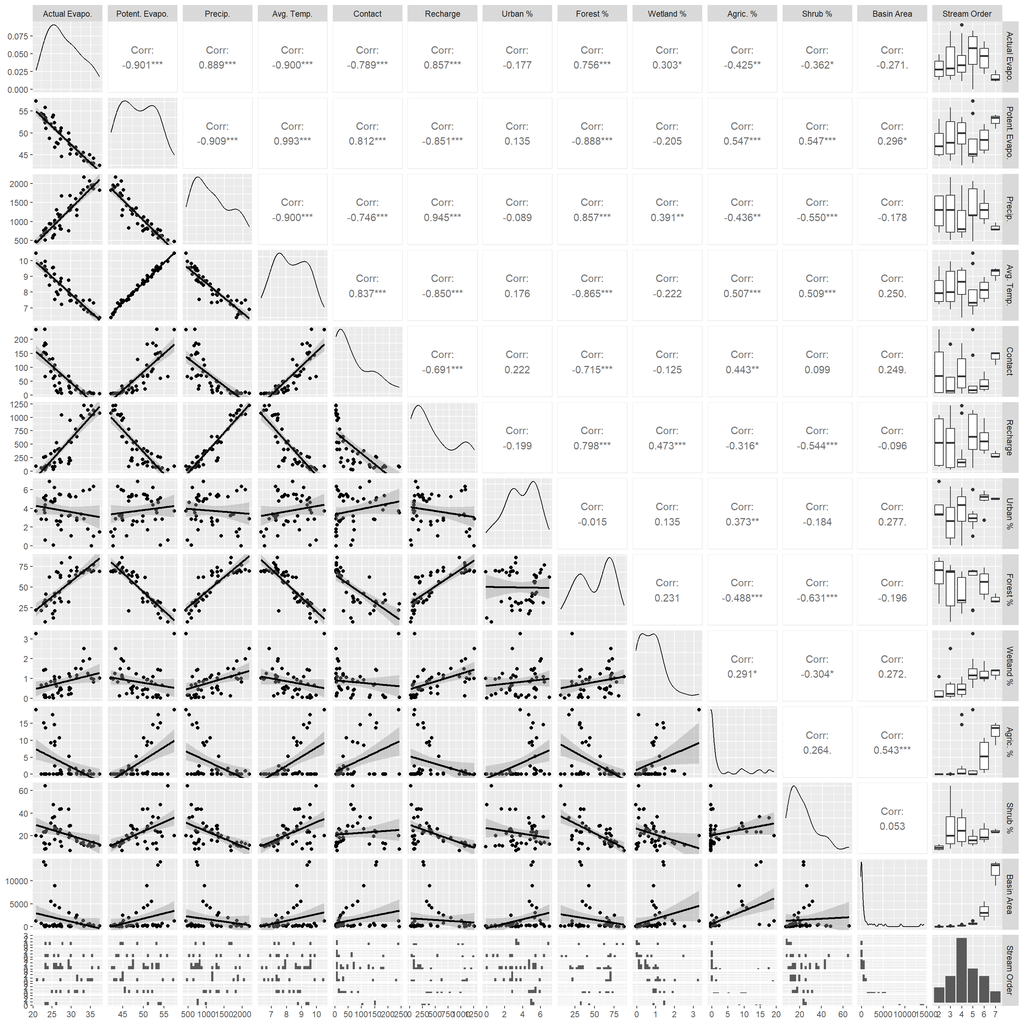

```r
supp.fig.1a
```

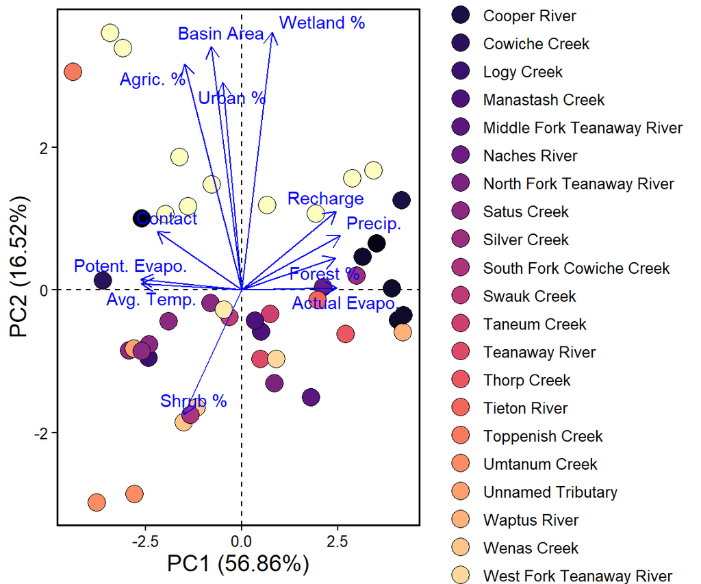

```r
ggsave("Figures/Supplemental_Figure_1a.pdf", supp.fig.1a, height = 15, width = 15)
supp.fig.1b
```

```r
ggsave("Figures/Supplemental_Figure_1b.pdf", supp.fig.1b, height = 7, width = 9.5)
```

## Parsing geochemistry data

This chunk of code is designed to import geochemical data from the data package available on ESS-DIVE.

```r
# Load in geochemistry
geochem = read.csv("v3_SFA_SpatialStudy_2021_SampleData/v3_SPS_Water_Sample_Data_Summary.csv", skip = 2)

# Delete unnecessary rows and columns
geochem = geochem[-1:-11,-1]
geochem = geochem[,-2:-7]
geochem = geochem[-nrow(geochem),]

# Set row names and clear column
row.names(geochem) = gsub("_Water", "", geochem[,1]); geochem = geochem[,-1]

# Remove unnecessary columns
geochem = geochem[,-which(colnames(geochem) %in% c("Material", "Mean_Missing_Reps"))]

# Set -9999 to NA
geochem[geochem == -9999] = NA

# # Remove columns with too many NAs
# w = which(apply(geochem, 2, function(x) length(which(is.na(x)))) > nrow(geochem)/2)
# geochem = geochem[,-w]
#
# rm(w)

# Converting remaining NaN-values to 0 as it looks like they were below detection
geochem[is.na(geochem)] = 0

# Converting columns to numeric
geochem.row = row.names(geochem)
geochem = as.data.frame(apply(geochem, 2, as.numeric))
row.names(geochem) = geochem.row; rm(geochem.row)

# Plotting geochemistry PCA
pca = prcomp(scale(geochem))

# Selecting plot objects for the PCA
scores.obj = data.frame(Site = row.names(pca$x), pca$x) %>% left_join(meta, by = "Site")
arrow.obj = data.frame(Variable = row.names(pca$rotation), pca$rotation*10) %>%
  mutate(Variable = case_when(Variable == "X00530_TSS_mg_per_L" ~ "TSS",
                              Variable == "Mean_00691_DIC_mg_per_L_as_C" ~ "DIC",
                              Variable == "X00940_Cl_mg_per_L" ~ "Cl",
                              Variable == "X00945_SO4_mg_per_L_as_SO4" ~ "SO4",
                              Variable == "X71851_NO3_mg_per_L_as_NO3" ~ "NO3",
                              Variable == "X71856_NO2_mg_per_L_as_NO2" ~ "NO2",
                              Variable == "Mean_00681_NPOC_mg_per_L_as_C" ~ "NPOC",
                              Variable == "Mean_00602_TN_mg_per_L_as_N" ~ "TN"  ))
signif.obj = summary(pca)$importance

# Plotting the PCA
supp.fig.2a = scores.obj %>%
  ggplot(aes(x = PC1, y = PC2))+
  geom_vline(xintercept = 0, lty = 2, lwd = 0.5)+
  geom_hline(yintercept = 0, lty = 2, lwd = 0.5)+
  geom_point(aes(fill = Location), shape = 21, size = 5, color = "black")+
  geom_segment(data = arrow.obj, aes(x = 0, xend = PC1, y = 0, yend = PC2),
               color = "blue", lwd = 0.5, arrow = arrow(length = unit(0.3, "cm")))+
  geom_text_repel(data = arrow.obj, aes(x = PC1, y = PC2,
                                        label = Variable), color = "blue")+
  xlab(paste0("PC1 (", round(signif.obj[2,1]*100, digits = 2), "%)"))+
  ylab(paste0("PC2 (", round(signif.obj[2,2]*100, digits = 2), "%)"))+
  guides(fill = guide_legend(ncol = 1))+
  scale_fill_viridis_d(option = "magma")+
  theme_bw() + theme(text = element_text(size = 12),
                     axis.title = element_text(color = "black", size = 14),
                     axis.text = element_text(color = "black"),
                     axis.ticks = element_line(color = "black"),
                     panel.border = element_rect(size = 1, color = "black"),
                     panel.background = element_blank(),
                     panel.grid = element_blank())

# Clean up
rm(scores.obj, arrow.obj, signif.obj, pca)
```

## Geochemistry compared to geospatial data

As a first pass, we decided it was a good idea to see how the specific geochemical variables varied in conjunciton with geospatial variables. This won’t necessary provide any striking conclusions on its own, but should help disentangle some potential patterns.

```r
# Plotting by stream order
supp.fig.2b = geochem %>% mutate(Site = row.names(geochem)) %>%
  gather(Variable, Concentration, -Site) %>%
  mutate(Variable = case_when(Variable == "X00530_TSS_mg_per_L" ~ "TSS",
                              Variable == "Mean_00691_DIC_mg_per_L_as_C" ~ "DIC",
                              Variable == "X00940_Cl_mg_per_L" ~ "Cl",
                              Variable == "X00945_SO4_mg_per_L_as_SO4" ~ "SO4",
                              Variable == "X71851_NO3_mg_per_L_as_NO3" ~ "NO3",
                              Variable == "X71856_NO2_mg_per_L_as_NO2" ~ "NO2",
                              Variable == "Mean_00681_NPOC_mg_per_L_as_C" ~ "NPOC",
                              Variable == "Mean_00602_TN_mg_per_L_as_N" ~ "TN"  )) %>%
  left_join(meta, by = "Site") %>%
  ggplot(aes(x = Stream_Order, y = Concentration, group = Stream_Order))+
  geom_boxplot() + ylab("Concentration (mg/L)")+
  facet_wrap(Variable~., ncol = 3, scales = "free_y")+
  stat_compare_means(method = "kruskal.test", label = "p.signif", vjust = 1,
                     aes(x = 4), color = "#cc0000ff")+
  xlab("Stream Order") + theme_bw()+
  theme(text = element_text(size = 12),
                     axis.title = element_text(color = "black", size = 14),
                     axis.text = element_text(color = "black"),
                     axis.ticks = element_line(color = "black"),
                     panel.border = element_rect(size = 1, color = "black"),
                     panel.background = element_blank(),
                     panel.grid = element_blank())

# Reconfirming meta order
if(!identical(meta$Site, row.names(geochem))){
  meta = meta[order(meta$Site),]

  if(!identical(meta$Site, row.names(geochem))){
    stop("Some sort of wizardry caused the sample order to be incorrect - please check that out.")
  }
}

# Correlating metadata and geochemistry
cor.val = cor(geochem[!is.na(meta$TOT_BASIN_AREA_LOG),],
              meta[!is.na(meta$TOT_BASIN_AREA_LOG),c("TOT_BASIN_AREA_LOG", "TOT_PPT2015_ANN", "TOT_urban16",
                                                     "TOT_forest16", "TOT_wetland16", "TOT_agrc16",
                                                     "TOT_shrub16", "Geospatial PC1", "Geospatial PC2",
                                                     "Geospatial PC3")],
              method = "spearman")
geo.var = row.names(cor.val)[-which(rowMaxs(abs(cor.val), value = T) < 0.5)] # https://journals.lww.com/anesthesia-analgesia/fulltext/2018/05000/correlation_coefficients__appropriate_use_and.50.aspx
meta.var = colnames(cor.val)[-which(colMaxs(abs(cor.val), value = T) < 0.5)]

# Plotting correlations with r-value > 0.5
supp.fig.2c = geochem[,geo.var] %>%
  mutate(Site = row.names(geochem)) %>%
  gather(Geochem, Geochem_Value, -Site) %>%
  mutate(Geochem = case_when(Geochem == "X00530_TSS_mg_per_L" ~ "TSS (mg/L)",
                              Geochem == "Mean_00691_DIC_mg_per_L_as_C" ~ "DIC (mg/L)",
                              Geochem == "X00940_Cl_mg_per_L" ~ "Cl (mg/L)",
                              Geochem == "X00945_SO4_mg_per_L_as_SO4" ~ "SO4 (mg/L)",
                              Geochem == "X71851_NO3_mg_per_L_as_NO3" ~ "NO3 (mg/L)",
                              Geochem == "X71856_NO2_mg_per_L_as_NO2" ~ "NO2 (mg/L)",
                              Geochem == "Mean_00681_NPOC_mg_per_L_as_C" ~ "NPOC (mg/L)",
                              Geochem == "Mean_00602_TN_mg_per_L_as_N" ~ "TN (mg/L)"  ))  %>%
  left_join(meta[,c("Site", meta.var)], by = "Site") %>%
  rename(`Basin Area` = TOT_BASIN_AREA_LOG,
         `Precip.`  = TOT_PPT2015_ANN,
         `Forest %`  = TOT_forest16,
         `Agric. %`  = TOT_agrc16,
         `Shrub %`  = TOT_shrub16) %>%
  gather(Geospat, Geospat_Value, -Site, -Geochem, -Geochem_Value) %>%
  ggplot(aes(x = Geospat_Value, Geochem_Value))+
  geom_point()+facet_grid(Geochem~Geospat, scales = "free")+
  xlab("Geospatial Value")+ylab("Concentration (mg/L)")+
  geom_smooth(method = "gam")+
  stat_cor(method = "spearman", cor.coef.name = "rho", label.sep = "\n",
           color = "#cc0000ff")+
  theme_bw()+theme(text = element_text(size = 12),
                     axis.title = element_text(color = "black", size = 14),
                     axis.text = element_text(color = "black"),
                     axis.ticks = element_line(color = "black"),
                     panel.border = element_rect(size = 1, color = "black"),
                     panel.background = element_blank(),
                     panel.grid = element_blank())
```

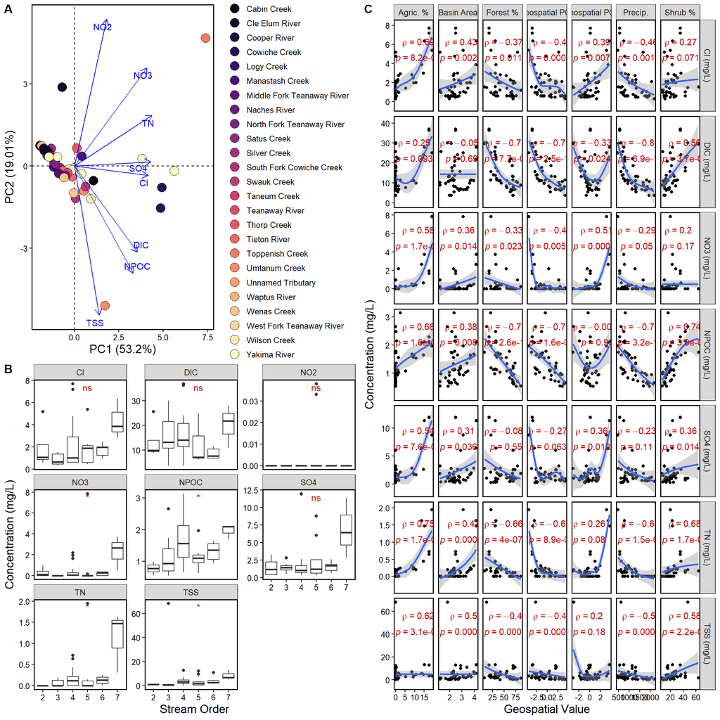

```r
supp.fig.2 = grid.arrange(ggarrange(supp.fig.2a, labels = "A"),
                          ggarrange(supp.fig.2b, labels = "B"),
                          ggarrange(supp.fig.2c, labels = "C"),
                          layout_matrix = rbind(c(1,1,3,3),
                                                c(2,2,3,3)))
```

```r
ggsave("Figures/Supplemental_Figure_2.pdf", supp.fig.2, width = 15, height = 12)
rm(supp.fig.2a, supp.fig.2b, supp.fig.2c)
```

## Overall Van Krevelen Diagrams

Just a basic VK diagram to help us orient ourselves to the general molecular landscape. While this is before the plot has been generated, the overarching molecular landscape within this data appears to be consistent with studies in other rivers (e.g., we see an enrichment of CRAM-like molecular formulas).

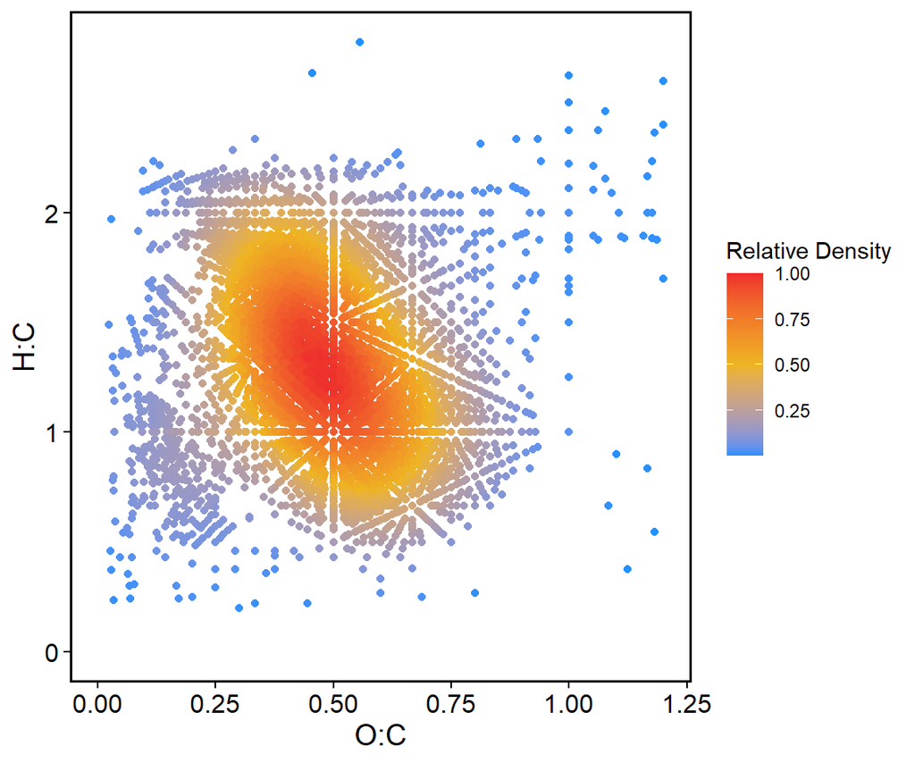

```r
# Generate VK plot
generate.vk(mol)
```

## Alpha-diversity

Various alpha diversity analyses to determine whether various metadata explain environmental metabolomic differences.

```r
# Load in MCD
mcd = read.tree("Data/RC2_SPS_03-2022_MCD_UPGMA.tre")

# Matching data and tree
phylo = match.phylo.data(mcd, data)

# Setting objects
data = phylo$data
mcd = phylo$phy
rm(phylo)

# Calculate alpha diversity
alpha.div = alpha.diver(data, mcd)

# Correlating all geospatial variables against alpha diversity
cor.spat = meta %>% select(Site, TOT_AET2015_ANN, TOT_PET2015_ANN, TOT_PPT2015_ANN,
                TOT_TAV2015_ANN, TOT_CONTACT, TOT_RECHG, TOT_urban16_sqrt,
                TOT_forest16_sqrt, TOT_wetland16_sqrt, TOT_agrc16_sqrt, TOT_shrub16_sqrt,
                TOT_BASIN_AREA_LOG, `Geospatial PC1`, `Geospatial PC2`,
                `Geospatial PC3`) # Create correlation object

geo.stats = NULL

for(curr.met in unique(alpha.div$variable)){
  temp.alpha = alpha.div[which(alpha.div$variable %in% curr.met),]
  temp.alpha = temp.alpha[order(temp.alpha$Site),]

  if(!identical(cor.spat$Site, temp.alpha$Site)){
    stop("The order between alpha diversity and geospatial data is wrong")
  }

  temp.alpha = temp.alpha[!is.na(cor.spat[,2]),]
  temp.cor = cor.spat[!is.na(cor.spat[,2]),]

  for(i in 2:ncol(cor.spat)){
    temp.res = rcorr(x = temp.cor[,i], y = temp.alpha$value, type = "spearman")
    temp.out = data.frame(Correlation = paste0(colnames(temp.cor)[i], " vs. ", curr.met),
                          Geospatial_Variable = colnames(temp.cor)[i],
                          Alpha_Div_Metric = curr.met,
                          rho = temp.res$r[1,2], p_value = temp.res$P[1,2])
    geo.stats = rbind(geo.stats, temp.out)
  }

  rm(temp.alpha, temp.cor, temp.res, temp.out)
}

# Adjust p-value
geo.stats$p_value = p.adjust(geo.stats$p_value, method = "fdr")

# Filter out insigniificant comparisons
geo.stats = geo.stats %>% filter(p_value < 0.05)

# Print significant geospatial variables
knitr::kable(geo.stats) %>%
  kable_styling()
```

| Correlation | Geospatial_Variable | Alpha_Div_Metric | rho | p_value |
| --- | --- | --- | --- | --- |
| TOT_PET2015_ANN vs. SR | TOT_PET2015_ANN | SR | 0.3827917197 | 0.0288783181 |
| TOT_TAV2015_ANN vs. SR | TOT_TAV2015_ANN | SR | 0.3341911246 | 0.0464664485 |
| TOT_CONTACT vs. SR | TOT_CONTACT | SR | 0.3649242512 | 0.0318181048 |
| TOT_agrc16_sqrt vs. SR | TOT_agrc16_sqrt | SR | 0.5329182370 | 0.0008629191 |
| TOT_shrub16_sqrt vs. SR | TOT_shrub16_sqrt | SR | 0.4325199491 | 0.0119760353 |
| TOT_BASIN_AREA_LOG vs. SR | TOT_BASIN_AREA_LOG | SR | 0.6416098069 | 0.0000176184 |
| Geospatial PC1 vs. SR | Geospatial PC1 | SR | -0.3596623106 | 0.0325669027 |
| TOT_PET2015_ANN vs. MCD_PD | TOT_PET2015_ANN | MCD_PD | 0.3951431056 | 0.0256291140 |
| TOT_TAV2015_ANN vs. MCD_PD | TOT_TAV2015_ANN | MCD_PD | 0.3446959876 | 0.0407498110 |
| TOT_CONTACT vs. MCD_PD | TOT_CONTACT | MCD_PD | 0.3710899110 | 0.0306883789 |
| TOT_agrc16_sqrt vs. MCD_PD | TOT_agrc16_sqrt | MCD_PD | 0.5724384731 | 0.0002619818 |
| TOT_shrub16_sqrt vs. MCD_PD | TOT_shrub16_sqrt | MCD_PD | 0.4463717845 | 0.0099667302 |
| TOT_BASIN_AREA_LOG vs. MCD_PD | TOT_BASIN_AREA_LOG | MCD_PD | 0.6566059566 | 0.0000161823 |
| Geospatial PC1 vs. MCD_PD | Geospatial PC1 | MCD_PD | -0.3787221747 | 0.0288783181 |

```r
# Correlating all geospatial variables against alpha diversity
cor.geo = geochem %>% mutate(Site = row.names(geochem)) %>%
  select(Site, colnames(geochem))

geo.stats = NULL

for(curr.met in unique(alpha.div$variable)){
  temp.alpha = alpha.div[which(alpha.div$variable %in% curr.met),]
  temp.alpha = temp.alpha[order(temp.alpha$Site),]

  if(!identical(cor.geo$Site, temp.alpha$Site)){
    stop("The order between alpha diversity and geospatial data is wrong")
  }

  for(i in 2:ncol(cor.geo)){
    temp.res = rcorr(x = cor.geo[,i], y = temp.alpha$value, type = "spearman")
    temp.out = data.frame(Correlation = paste0(colnames(cor.geo)[i], " vs. ", curr.met),
                          Geospatial_Variable = colnames(cor.geo)[i],
                          Alpha_Div_Metric = curr.met,
                          rho = temp.res$r[1,2], p_value = temp.res$P[1,2])
    geo.stats = rbind(geo.stats, temp.out)
  }

  rm(temp.alpha, temp.cor, temp.res, temp.out)
}

# Adjust p-value
geo.stats$p_value = p.adjust(geo.stats$p_value, method = "fdr")

# Filter out insigniificant comparisons
geo.stats = geo.stats %>% filter(p_value < 0.05)

# Print significant geospatial variables
knitr::kable(geo.stats) %>%
  kable_styling()
```

| Correlation | Geospatial_Variable | Alpha_Div_Metric | rho | p_value |
| --- | --- | --- | --- | --- |
| X00530_TSS_mg_per_L vs. SR | X00530_TSS_mg_per_L | SR | 0.6830784356 | 0.0000009779 |
| X00940_Cl_mg_per_L vs. SR | X00940_Cl_mg_per_L | SR | 0.4501980515 | 0.0029946747 |
| Mean_00681_NPOC_mg_per_L_as_C vs. SR | Mean_00681_NPOC_mg_per_L_as_C | SR | 0.5210905203 | 0.0005537029 |
| Mean_00602_TN_mg_per_L_as_N vs. SR | Mean_00602_TN_mg_per_L_as_N | SR | 0.5019063768 | 0.0008670710 |
| X00530_TSS_mg_per_L vs. MCD_PD | X00530_TSS_mg_per_L | MCD_PD | 0.7112254636 | 0.0000003376 |
| X00940_Cl_mg_per_L vs. MCD_PD | X00940_Cl_mg_per_L | MCD_PD | 0.4922374184 | 0.0010073422 |
| X71851_NO3_mg_per_L_as_NO3 vs. MCD_PD | X71851_NO3_mg_per_L_as_NO3 | MCD_PD | 0.3377838637 | 0.0359615765 |
| Mean_00681_NPOC_mg_per_L_as_C vs. MCD_PD | Mean_00681_NPOC_mg_per_L_as_C | MCD_PD | 0.5367870258 | 0.0004013864 |
| Mean_00602_TN_mg_per_L_as_N vs. MCD_PD | Mean_00602_TN_mg_per_L_as_N | MCD_PD | 0.5427086782 | 0.0004013864 |

```r
# Generate alpha diversity plots for significant geospatial data
plot1.so = plot.alpha.diver(alpha.div, meta, "Stream_Order",
                            "Formulas") # Included given that it is factorial
plot2.pc = plot.alpha.diver(alpha.div, cor.spat, "Geospatial PC1",
                            "Formulas") # PET and TAV are co-linear
plot3.con = plot.alpha.diver(alpha.div, cor.spat, "TOT_CONTACT",
                             "Formulas")
plot4.ba = plot.alpha.diver(alpha.div, cor.spat, "TOT_BASIN_AREA_LOG",
                            "Formulas")
plot5.ag = plot.alpha.diver(alpha.div, cor.spat, "TOT_agrc16_sqrt",
                            "Formulas")
plot7.sh = plot.alpha.diver(alpha.div, cor.spat, "TOT_shrub16_sqrt",
                            "Formulas")

# Generate alpha diversity plots for significant geochemical variables
plot8.cl = plot.alpha.diver(alpha.div, cor.geo, "X00940_Cl_mg_per_L",
                            "Formulas")
plot9.oc = plot.alpha.diver(alpha.div, cor.geo, "Mean_00681_NPOC_mg_per_L_as_C",
                            "Formulas")
plot10.tn = plot.alpha.diver(alpha.div, cor.geo, "Mean_00602_TN_mg_per_L_as_N",
                             "Formulas")
plot11.tss = plot.alpha.diver(alpha.div, cor.geo, "X00530_TSS_mg_per_L",
                              "Formulas")
plot12.no3 = plot.alpha.diver(alpha.div, cor.geo, "X71851_NO3_mg_per_L_as_NO3",
                              "Formulas")
```

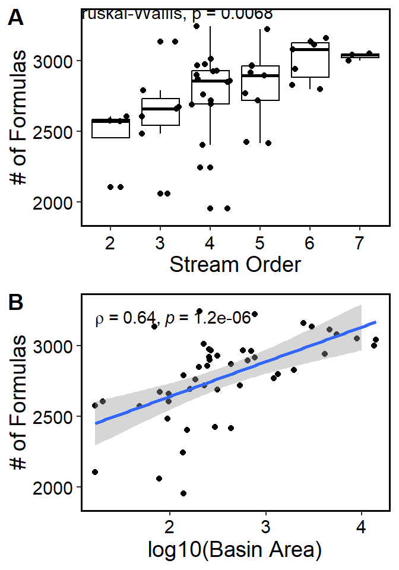

```r
# Merge figure 1 (e.g., stream order/basin area vs. formulas)
fig.1 = ggarrange(plot1.so$Plot + xlab("Stream Order") + ylab("# of Formulas")+
                    ylim(1900, 3300) +
                    theme(axis.text.x = element_text(angle = 0 , hjust = 0.5)),
                  plot4.ba$Plot + xlab("log10(Basin Area)") + ylab("# of Formulas")+
                    ylim(1900, 3300),
                  labels = c("A", "B"),
                  nrow = 2, ncol = 1)

fig.1
```

```r
ggsave("Figures/Figure_1.pdf", fig.1, width = 3.5, height = 5)
```

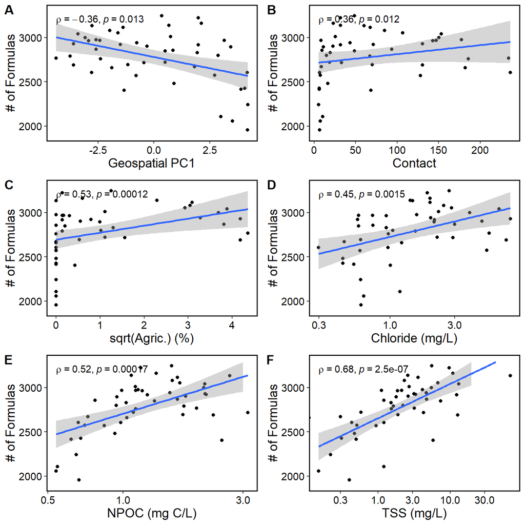

```r
# Combine plots
fig.2 = ggarrange(plot2.pc$Plot + xlab("Geospatial PC1") +
                    ylab("# of Formulas")+
                    ylim(1900, 3300),
                  plot3.con$Plot + xlab("Contact") +
                    ylab("# of Formulas")+
                    ylim(1900, 3300),
                  plot5.ag$Plot + xlab("sqrt(Agric.) (%)") +
                    ylab("# of Formulas")+
                    ylim(1900, 3300),
                  plot8.cl$Plot + xlab("Chloride (mg/L)") +
                    ylab("# of Formulas")+
                    scale_x_log10()+
                    ylim(1900, 3300),
                  plot9.oc$Plot + xlab("NPOC (mg C/L)") +
                    ylab("# of Formulas")+
                    scale_x_log10()+
                    ylim(1900, 3300),
                  plot11.tss$Plot + xlab("TSS (mg/L)") +
                    ylab("# of Formulas")+
                    scale_x_log10()+
                    ylim(1900, 3300), nrow = 3, ncol = 2,
                  labels = c("A", "B", "C", "D", "E", "F"))

fig.2
```

```r
rm(list = ls(pattern = "^plot[0-9].*"))
```

## Mutlivariate DOM composition vs. geospatial/geochemical relationships

Multivariate comparisons will enable us to detect consistencies across two large datasets - here, we are looking how the FTICR-MS-based DOM composition data relates to both geospatial and geochemical datasets. In order to accomplish these comparisons, we are using a permuted Procrustes test in order to see whether one dataset is a reprojection of the other.

```r
# Generate taxonomic distance matrix
d = vegdist(t(data), method = "jaccard")

# Generate phylogenetic distance matrix
pd = comdistnt_fast(t(data), cophenetic(mcd), abundance.weighted = F, exclude.conspecifics = F)

# Create geospatial and geochemical distance matrices
spat.dist = meta %>% select(TOT_AET2015_ANN, TOT_PET2015_ANN, TOT_PPT2015_ANN,
                TOT_TAV2015_ANN, TOT_CONTACT, TOT_RECHG, TOT_urban16_sqrt,
                TOT_forest16_sqrt, TOT_wetland16_sqrt, TOT_agrc16_sqrt, TOT_shrub16_sqrt,
                TOT_BASIN_AREA_LOG) %>% vegdist(method = "euclidean")
geo.dist = geochem %>% vegdist(method = "euclidean")

# Permuted Procrustes analysis for tax/phy distances
tax.spat.prot = protest(d, spat.dist)
phy.spat.prot = protest(pd, spat.dist)

tax.geo.prot = protest(d, geo.dist)
phy.geo.prot = protest(pd, geo.dist)

# Printing results
tax.spat.prot
```

```
##
## Call:
## protest(X = d, Y = spat.dist)
##
## Procrustes Sum of Squares (m12 squared):        0.639567
## Correlation in a symmetric Procrustes rotation: 0.6003607
## Significance:  0.001
##
## Permutation: free
## Number of permutations: 999
```

```r
phy.spat.prot
```

```
##
## Call:
## protest(X = pd, Y = spat.dist)
##
## Procrustes Sum of Squares (m12 squared):        0.5717619
## Correlation in a symmetric Procrustes rotation: 0.6543991
## Significance:  0.001
##
## Permutation: free
## Number of permutations: 999
```

```r
tax.geo.prot
```

```
##
## Call:
## protest(X = d, Y = geo.dist)
##
## Procrustes Sum of Squares (m12 squared):        0.8431852
## Correlation in a symmetric Procrustes rotation: 0.3959984
## Significance:  0.005
##
## Permutation: free
## Number of permutations: 999
```

```r
phy.geo.prot
```

```
##
## Call:
## protest(X = pd, Y = geo.dist)
##
## Procrustes Sum of Squares (m12 squared):        0.8452125
## Correlation in a symmetric Procrustes rotation: 0.3934304
## Significance:  0.011
##
## Permutation: free
## Number of permutations: 999
```

As suggested by patterns observed with the alpha diversity data, we see that the geospatial data better captures the multivariate patterns of the DOM data than the geochemical data. We have decided against generating any NMDS/ordiations in favor of utilizing more aggregated analyses like an RDA.